# Bridging resilience factors and successful ageing dimensions: A network analysis

Timothy

2026-02-18

# Chunk options

```r
knitr::opts_chunk$set(
  echo      = TRUE,
  message   = FALSE,
  warning   = FALSE,
  error     = FALSE)
```

# Environment

```r
rm(list = ls(all.names = TRUE))
seed <- 1337
options(scipen = 999)
cat("\014")
```

# Packages

```r
packages <- c(
  "conflicted"

# hardware
, "parallel"             # detectCores()

# knitting
, "rmarkdown"

# data management
, "tidyverse"
, "dplyr"
, "tidyr"
, "knitr"
, "rmarkdown"            # paged_table()
, "readxl"
, "forcats"              # fct_infreq()
, "Hmisc"                # rcorr()

# statistical tests
, "matrixcalc"           # is.positive.definite()
, "rstatix"
, "psych"
, "dlookr"               # find_skewness()

# visualisation
, "ggplot2"
, "ggcorrplot"           # ggcorrplot()
, "devtools"

# computational tools
, "missRanger"           # missRanger()

# network tools
, "networktools"         # goldbricker()
, "bootnet"
, "igraph"
, "mgm"
, "qgraph"
, "NetworkToolbox"
)

invisible(lapply(packages,
  \(p) {if (!requireNamespace(p, quietly = TRUE)) install.packages(p)
        library(p, character.only = TRUE)}))
```

# Functions

Functions deconflicted with the **conflicted** package (Wickham, 2024).

**Author**: Wickham, H. (2024). *conflicted: An alternative conflict resolution strategy (Version 1.2.0)* [R package]. CRAN.

```r
conflict_scout()

functions <- c(
  filter    = "dplyr",
  recode    = "dplyr",
  select    = "dplyr",
  describe  = "psych",
  summarize = "dplyr",
  mutate    = "dplyr")

invisible(lapply(names(functions), function(f) conflict_prefer(f, functions[f])))
```

# Data

```r
# Original dataset accessible at https://osf.io/7xcmy/files/f68nh.
# Codebook accessible at https://www.icpsr.umich.edu/web/NAHDAP/series/706/variables.
```

# Import

Dataset imported with the **readxl** package (Wickham & Bryan, 2025).

**Author**: Wickham, H., & Bryan, J. (2025). *readxl: Read Excel files (Version 1.4.5)* [R package]. CRAN.

```r
raw <- read_excel("Networks_Dataset_140226.xlsx"
, sheet = "34921-0001-Data"
, skip = 10
, col_names = TRUE)

save(raw, file = "raw.RData")
```

```r
load("raw.RData")
```

# Variables

```r
df <- raw %>% select(
# number of major diseases (later reversed)
  chr1  = STROKE...22
, chr2  = ALZHEIMER...25
, chr3  = DEMENTIA...26
, chr4  = PARKINSON...27
, chr5  = CANCER
, chr6  = `HYPERTENSION (CONDITNS_6)`
, chr7  = `DIABETES(CONDITNS_7)`
, chr8  = `EMPHYSEMA/ASTHMA (EMPHASTH)`
, chr9  = ARTHRITIS...92
, chr10 = `HEART PROBLEMS (HRTPROB2)`

# difficulties with adls (later reversed)
, adl1  = PREPMEAL
, adl2  = TAKEMEDS
, adl3  = MANAGEMONEY
, adl4  = SHOPFOOD
, adl5  = LIGHTWORK
, adl6  = USETELEP
, adl7  = WALKROOM
, adl8  = BATHING
, adl9  = EATING
, adl10 = INOUTBED
, adl11 = TOILET

# self-rated physical health
, phy   = PHYSHLTH...82

# cognitive performance
, cog   = MOCA...17

# frequency of socialising
, soc   = SOCIAL

# community participation
, com1  = VOLUNTEER
, com2  = ATTEND
, com3  = ATNDSERV2

# depression
, dep1  = NOTEAT
, dep2  = FLTDEP
, dep3  = FLTEFF
, dep4  = NOSLEEP
, dep5r = WASHAPY # to reverse
, dep6  = WASLONLY
, dep7  = UNFRIEND
, dep8r = ENJLIFE # to reverse
, dep9  = FLTSAD
, dep10 = DISLIKD

# anxiety
, anx1  = FLTTENS
, anx2  = FRIGHT
, anx3  = WORRY
, anx4r = RELAXED # to reverse
, anx5  = BUTRFLY
, anx6  = RESTLES
, anx7  = PANIC

# happiness
, hap   = HAPPY

# loneliness
, lon1  = COMPANION2
, lon2  = LEFTOUT2
, lon3  = ISOLATED2

# self-rated mental health
, men   = MNTLHLTH...64

# physical activity
, act   = PHYSACT2...12

# alcohol consumption per week
, alc   = DRNKWKLY

# cigarettes per day
, smk   = AVECIG

# weight and height
, wei   = WEIGHT...61
, hei   = HEIGHT

# age
, age   = AGE

# educational attainment
, edu   = EDUC...151

# number of friends
, fri   = FRAMT

# income
, inc   = INCOME_1...8)

df %>% describe() %>% paged_table()
```

|  | vars | n | mean | sd | median | trimmed | mad | min | max | range | skew | kurtosis | se |
| --- | --- | --- | --- | --- | --- | --- | --- | --- | --- | --- | --- | --- | --- |
| chr1 | 1 | 3185 | 0.095447410 | 0.29387807 | 0.00000 | 0.00000000 | 0.000000 | 0.0000000 | 1.000 | 1.000000 | 2.75233588 | 5.5771041 | 0.005207298 |
| chr2 | 2 | 3191 | 0.008461297 | 0.09160968 | 0.00000 | 0.00000000 | 0.000000 | 0.0000000 | 1.000 | 1.000000 | 10.72778886 | 113.1209042 | 0.001621728 |
| chr3 | 3 | 3158 | 0.012666244 | 0.11184709 | 0.00000 | 0.00000000 | 0.000000 | 0.0000000 | 1.000 | 1.000000 | 8.71152623 | 73.9140950 | 0.001990300 |
| chr4 | 4 | 3191 | 0.010968348 | 0.10417027 | 0.00000 | 0.00000000 | 0.000000 | 0.0000000 | 1.000 | 1.000000 | 9.38614086 | 86.1266310 | 0.001844083 |
| chr5 | 5 | 3196 | 0.293538798 | 0.52740202 | 0.00000 | 0.19785379 | 0.000000 | 0.0000000 | 2.000 | 2.000000 | 1.60538800 | 1.6637777 | 0.009329071 |
| chr6 | 6 | 3196 | 0.620813517 | 0.48522221 | 1.00000 | 0.65094605 | 0.000000 | 0.0000000 | 1.000 | 1.000000 | -0.49761736 | -1.7529186 | 0.008582964 |
| chr7 | 7 | 3196 | 0.237515645 | 0.42559095 | 0.00000 | 0.17204848 | 0.000000 | 0.0000000 | 1.000 | 1.000000 | 1.23321080 | -0.4793315 | 0.007528163 |
| chr8 | 8 | 3196 | 0.154593242 | 0.36153878 | 0.00000 | 0.06844410 | 0.000000 | 0.0000000 | 1.000 | 1.000000 | 1.91023708 | 1.6495364 | 0.006395161 |
| chr9 | 9 | 3196 | 0.351821026 | 0.47747694 | 0.00000 | 0.31486317 | 0.000000 | 0.0000000 | 1.000 | 1.000000 | 0.62088922 | -1.6149773 | 0.008445960 |
| chr10 | 10 | 3196 | 0.283826658 | 0.45088649 | 0.00000 | 0.22991009 | 0.000000 | 0.0000000 | 1.000 | 1.000000 | 0.95868320 | -1.0812564 | 0.007975609 |

[output cut: 48 more lines]

# Values

```r
df$chr5[df$chr5 == 0.02] <- 1
df$chr5[df$chr5 == 0.01] <- 1

recode_map <- list(

# from codebook
  alc  = c(-3, 0)
, smk  = c(-3, 0)
, men  = c(2.5, 0)
, phy  = c(2.5, 0)
, inc  = c(2.7, 0)

# researcher-derived
, chr1 = c(0.01, 1)
, chr2 = c(0.01, 1)
, chr3 = c(0.01, 1)
, chr4 = c(0.01, 1)
, chr5 = c(0.02, 1)
, chr5 = c(0.01, 1)
, chr6 = c(0.01, 1)
, chr7 = c(0.01, 1)
, chr8 = c(0.01, 1)
, chr9 = c(0.01, 1)
, chr10 = c(0.01, 1)
, chr5 = c(2, 1)
)

for (v in names(recode_map)) {
  from <- recode_map[[v]][1]
  to   <- recode_map[[v]][2]
  df[[v]][df[[v]] == from] <- to
}

na_rules <- list(

# replace invalid values
  chr1 = list(discrete = c(-8, -6, -5, -4, -3, -2, -1), range = list(c(0, 1)))
, chr2 = list(discrete = c(-8, -6, -5, -4, -3, -2, -1), range = list(c(0, 1)))
, chr3 = list(discrete = c(-8, -6, -5, -4, -3, -2, -1), range = list(c(0, 1)))
, chr4 = list(discrete = c(-8, -6, -5, -4, -3, -2, -1), range = list(c(0, 1)))
, chr5 = list(discrete = c(-8, -6, -5, -4, -3, -2, -1), range = list(c(0, 1)))
, chr6 = list(discrete = c(-8, -6, -5, -4, -3, -2, -1), range = list(c(0, 1)))
, chr7 = list(discrete = c(-8, -6, -5, -4, -3, -2, -1), range = list(c(0, 1)))
, chr8 = list(discrete = c(-8, -6, -5, -4, -3, -2, -1), range = list(c(0, 1)))
, chr9 = list(discrete = c(-8, -6, -5, -4, -3, -2, -1), range = list(c(0, 1)))
, chr10 = list(discrete = c(-8, -6, -5, -4, -3, -2, -1), range = list(c(0, 1)))

, adl1 = list(discrete = c(-8, -3, -2, -1, 4), range = list(c(0, 3)))
, adl2 = list(discrete = c(-8, -3, -2, -1, 4), range = list(c(0, 3)))
, adl3 = list(discrete = c(-8, -3, -2, -1, 4), range = list(c(0, 3)))
, adl4 = list(discrete = c(-8, -3, -2, -1, 4), range = list(c(0, 3)))
, adl5 = list(discrete = c(-8, -3, -2, -1, 4), range = list(c(0, 3)))
, adl6 = list(discrete = c(-8, -3, -2, -1, 4), range = list(c(0, 3)))
, adl7 = list(discrete = c(-8, -3, -2, -1, 4), range = list(c(0, 3)))
, adl8 = list(discrete = c(-8, -3, -2, -1, 4), range = list(c(0, 3)))
, adl9 = list(discrete = c(-8, -3, -2, -1, 4), range = list(c(0, 3)))
, adl10 = list(discrete = c(-8, -3, -2, -1, 4), range = list(c(0, 3)))
, adl11 = list(discrete = c(-8, -3, -2, -1, 4), range = list(c(0, 3)))

, phy = list(discrete = c(-4, -3, -2, -1), range = list(c(1, 5)))
, cog = list(discrete = c(-4, -3, -2, -1), range = list(c(0, 30)))

, com1 = list(discrete = c(-5, -4, -3, -2, -1), range = list(c(0, 6)))
, com2 = list(discrete = c(-5, -4, -3, -2, -1), range = list(c(0, 6)))
, com3 = list(discrete = c(-8, -5, -4, -3, -2, -1), range = list(c(0, 5)))

, soc = list(discrete = c(-5, -4, -3, -2, -1), range = list(c(0, 6)))

, dep1 = list(discrete = c(-8, -3, -2, -1), range = list(c(1, 4)))
, dep2 = list(discrete = c(-8, -3, -2, -1), range = list(c(1, 4)))
, dep3 = list(discrete = c(-8, -3, -2, -1), range = list(c(1, 4)))
, dep4 = list(discrete = c(-8, -3, -2, -1), range = list(c(1, 4)))
, dep5r = list(discrete = c(-8, -3, -2, -1), range = list(c(1, 4)))
, dep6 = list(discrete = c(-8, -3, -2, -1), range = list(c(1, 4)))
, dep7 = list(discrete = c(-8, -3, -2, -1), range = list(c(1, 4)))
, dep8r = list(discrete = c(-8, -3, -2, -1), range = list(c(1, 4)))
, dep9 = list(discrete = c(-8, -3, -2, -1), range = list(c(1, 4)))
, dep10 = list(discrete = c(-8, -3, -2, -1), range = list(c(1, 4)))

, anx1 = list(discrete = c(-8, -6, -5, -4, -3, -2, -1), range = list(c(1, 4)))
, anx2 = list(discrete = c(-8, -6, -5, -4, -3, -2, -1), range = list(c(1, 4)))
, anx3 = list(discrete = c(-8, -6, -5, -4, -3, -2, -1), range = list(c(1, 4)))
, anx4r = list(discrete = c(-8, -6, -5, -4, -3, -2, -1), range = list(c(1, 4)))
, anx5 = list(discrete = c(-8, -6, -5, -4, -3, -2, -1), range = list(c(1, 4)))
, anx6 = list(discrete = c(-8, -6, -5, -4, -3, -2, -1), range = list(c(1, 4)))
, anx7 = list(discrete = c(-8, -6, -5, -4, -3, -2, -1), range = list(c(1, 4)))

, hap = list(discrete = c(-8, -4, -3, -2, -1), range = list(c(1, 5)))

, lon1 = list(discrete = c(-8, -5, -4, -3, -2, -1), range = list(c(0, 3)))
, lon2 = list(discrete = c(-8, -5, -4, -3, -2, -1), range = list(c(0, 3)))
, lon3 = list(discrete = c(-8, -5, -4, -3, -2, -1), range = list(c(0, 3)))

, men = list(discrete = c(-3, -2, -1), range = list(c(1, 5)))
, act = list(discrete = c(-8, -3, -2, -1), range = list(c(0, 5)))
, alc = list(discrete = c(-8, -2, -1), range = list(c(0, 7)))
, smk = list(discrete = c(-8, -6, -5, -4, -2, -1), range = list(c(0, 60)))

, wei = list(discrete = c(-8, -6, -5, -4, -3, -2, -1), range = list(c(70, 400)))
, hei = list(discrete = c(-8, -6, -5, -4, -3, -2, -1), range = list(c(30, 90)))
, age = list(discrete = c(-8, -6, -5, -4, -3, -2, -1), range = list(c(61, 91)))

, edu = list(discrete = c(-8, -6, -5, -4, -3, -2, -1), range = list(c(1, 4)))
, fri = list(discrete = c(-5, -4, -3, -2, -1), range = list(c(0, 5)))
, inc = list(discrete = c(-5, -4, -2, -1), range = list(c(1, 5))))

vars <- names(na_rules)

convert_to_na <- function(x, discrete_vals, ranges) {
  is_na <- x %in% discrete_vals
  for (r in ranges) is_na <- is_na | (x < r[1] | x > r[2])
  x[is_na] <- NA
  x}

df[vars] <- lapply(vars, \(v) convert_to_na(df[[v]], na_rules[[v]]$discrete, na_rules[[v]]$range))

df %>% describe() %>% paged_table()
```

|  | vars | n | mean | sd | median | trimmed | mad | min | max | range | skew | kurtosis | se |
| --- | --- | --- | --- | --- | --- | --- | --- | --- | --- | --- | --- | --- | --- |
| chr1 | 1 | 3185 | 0.095447410 | 0.29387807 | 0.00000 | 0.00000000 | 0.000000 | 0 | 1 | 1 | 2.75233588 | 5.57710413 | 0.005207298 |
| chr2 | 2 | 3191 | 0.008461297 | 0.09160968 | 0.00000 | 0.00000000 | 0.000000 | 0 | 1 | 1 | 10.72778886 | 113.12090420 | 0.001621728 |
| chr3 | 3 | 3158 | 0.012666244 | 0.11184709 | 0.00000 | 0.00000000 | 0.000000 | 0 | 1 | 1 | 8.71152623 | 73.91409495 | 0.001990300 |
| chr4 | 4 | 3191 | 0.010968348 | 0.10417027 | 0.00000 | 0.00000000 | 0.000000 | 0 | 1 | 1 | 9.38614086 | 86.12663103 | 0.001844083 |
| chr5 | 5 | 3079 | 0.232867814 | 0.42272737 | 0.00000 | 0.16632860 | 0.000000 | 0 | 1 | 1 | 1.26344042 | -0.40384914 | 0.007618255 |
| chr6 | 6 | 3196 | 0.624530663 | 0.48431963 | 1.00000 | 0.65559030 | 0.000000 | 0 | 1 | 1 | -0.51408900 | -1.73625546 | 0.008566998 |
| chr7 | 7 | 3196 | 0.240613267 | 0.42752276 | 0.00000 | 0.17591869 | 0.000000 | 0 | 1 | 1 | 1.21306090 | -0.52864836 | 0.007562334 |
| chr8 | 8 | 3196 | 0.157071339 | 0.36392496 | 0.00000 | 0.07154027 | 0.000000 | 0 | 1 | 1 | 1.88402228 | 1.55002522 | 0.006437370 |
| chr9 | 9 | 3196 | 0.364831039 | 0.48145808 | 0.00000 | 0.33111806 | 0.000000 | 0 | 1 | 1 | 0.56132267 | -1.68544392 | 0.008516381 |
| chr10 | 10 | 3196 | 0.287234043 | 0.45254251 | 0.00000 | 0.23416732 | 0.000000 | 0 | 1 | 1 | 0.94001946 | -1.11671253 | 0.008004902 |

[output cut: 48 more lines]

# Missing

```r
colSums(is.na(df))
```

```
##  chr1  chr2  chr3  chr4  chr5  chr6  chr7  chr8  chr9 chr10  adl1  adl2  adl3
##    11     5    38     5   117     0     0     0     0     0    86    26    71
##  adl4  adl5  adl6  adl7  adl8  adl9 adl10 adl11   phy   cog   soc  com1  com2
##    44    50     0     0     0     0     1     0     6     3   443   448   452
##  com3  dep1  dep2  dep3  dep4 dep5r  dep6  dep7 dep8r  dep9 dep10  anx1  anx2
##    11     5     4     7     3     4     2    12     5     6    18   546   571
##  anx3 anx4r  anx5  anx6  anx7   hap  lon1  lon2  lon3   men   act   alc   smk
##   560   564   569   574   573     9   492   523   588     4     0     8     3
##   wei   hei   age   edu   fri   inc
##     0   124     1     1    59   581
```

```r
print(paste("Percentage of data that is missing:",
            round(sum(is.na(df)) / prod(dim(df)) * 100, 2), "%"))
```

```
## [1] "Percentage of data that is missing: 4.44 %"
```

```r
print(paste("Rows with complete data:", sum(complete.cases(df)), "/",
            nrow(df), "(", round(sum(complete.cases(df)) / nrow(df) * 100, 2), "%)"))
```

```
## [1] "Rows with complete data: 1891 / 3196 ( 59.17 %)"
```

# Imputation

Missing values imputed with the **missRanger** package (Mayer & Mayer, 2019).

**Author**: Mayer, M., & Mayer, M. M. (2019). *Package ‘missRanger’.* [R package], 820. CRAN.

```r
set.seed(seed)
dfimputed <- missRanger(
  as.data.frame(df)
, pmm.k = 5 # predictive mean matching
, seed = seed
, verbose = 0)
dfimputed %>% paged_table()
dfimputed %>% describe()

data <- dfimputed

save(data, file = "data.RData")
```

```r
load("data.RData")
```

# Casewise deletion

```r
# SKIPPED
data <- dfimputed

dffullrows <- df[complete.cases(df), ]
dffullrows %>% paged_table()

# data <- dffullrows
```

# Recoding

```r
reverse_scale <- function(x, min, max) {
  ifelse(is.na(x), NA, max + min - x)}

data <- data %>%
  mutate(data
, dep5 = reverse_scale(dep5r, min = 1, max = 4)
, dep8 = reverse_scale(dep8r, min = 1, max = 4)
, anx4 = reverse_scale(anx4r, min = 1, max = 4)) %>%
  select(-dep5r, -dep8r, -anx4r)

sum_vars <- list(
  chr = paste0("chr", 1:10)
, adl = paste0("adl", 1:11)
, dep = paste0("dep", 1:10)
, anx = paste0("anx", 1:7)
, lon = paste0("lon", 1:3)
, com = paste0("com", 1:3))

sum_scale <- function(dat, cols, require_at_least = 0) {
  n_ok <- rowSums(!is.na(dat[, cols, drop = FALSE]))
  s    <- rowSums(dat[, cols, drop = FALSE], na.rm = TRUE)
  s[n_ok < require_at_least] <- NA
  s}

# full data
mins_required <- c(
  chr = 10
, adl = 11
, dep = 10
, anx = 7
, lon = 3
, com = 3)

for (v in names(sum_vars)) {
  data[[v]] <- sum_scale(data, sum_vars[[v]], require_at_least = mins_required[[v]])
  data <- data %>% select(-all_of(sum_vars[[v]]))}

# reversing scales
data <- data %>%
  mutate(
  chr = reverse_scale(chr, min = 1, max = 10)
, adl = reverse_scale(adl, min = 1, max = 33))

# conversion
data <- data %>% mutate(bmi = wei*0.453592/((hei*2.54/100)^2)) %>% select(-wei, -hei)

# reorder columns
SA <- c(
  "chr"
, "adl"
, "phy"
, "cog"
, "soc"
)

data <- data %>% select(all_of(SA), everything())

data %>% paged_table()
```

| chr | adl | phy | cog | soc | hap | men | act | alc | smk | age | edu | fri | inc | dep | anx | lon | com | bmi |
| --- | --- | --- | --- | --- | --- | --- | --- | --- | --- | --- | --- | --- | --- | --- | --- | --- | --- | --- |
| 10 | 34 | 4 | 24.6153846 | 4 | 4 | 4 | 5 | 1 | 0 | 69 | 4 | 4 | 3 | 10 | 7 | 1 | 14 | 26.07345 |
| 8 | 33 | 4 | 26.9230769 | 6 | 4 | 4 | 5 | 6 | 0 | 82 | 4 | 2 | 5 | 12 | 12 | 3 | 8 | 22.22472 |
| 10 | 34 | 5 | 26.1538462 | 4 | 4 | 4 | 5 | 7 | 0 | 72 | 4 | 5 | 4 | 12 | 8 | 1 | 14 | 20.01008 |
| 9 | 34 | 4 | 29.2307692 | 3 | 4 | 5 | 4 | 4 | 0 | 74 | 4 | 4 | 4 | 11 | 10 | 3 | 15 | 24.34157 |
| 8 | 34 | 5 | 19.2307692 | 5 | 3 | 5 | 5 | 3 | 0 | 79 | 3 | 4 | 5 | 17 | 11 | 5 | 7 | 20.82091 |
| 10 | 34 | 5 | 26.9230769 | 6 | 3 | 4 | 5 | 5 | 0 | 66 | 4 | 3 | 5 | 15 | 7 | 6 | 15 | 22.66101 |
| 9 | 34 | 4 | 23.8461538 | 5 | 4 | 5 | 5 | 6 | 0 | 88 | 4 | 4 | 4 | 12 | 7 | 1 | 10 | 18.02301 |
| 8 | 32 | 2 | 25.3846154 | 5 | 4 | 3 | 3 | 4 | 0 | 74 | 4 | 4 | 3 | 12 | 16 | 3 | 15 | 28.72696 |
| 10 | 34 | 5 | 26.1538462 | 5 | 5 | 4 | 5 | 7 | 0 | 81 | 4 | 4 | 5 | 10 | 10 | 3 | 12 | 26.15065 |
| 10 | 34 | 4 | 26.9230769 | 5 | 4 | 4 | 5 | 7 | 0 | 75 | 4 | 3 | 3 | 12 | 8 | 4 | 13 | 23.56741 |

[output cut: 3186 more lines]

```r
data %>% describe %>% paged_table()
```

|  | vars | n | mean | sd | median | trimmed | mad | min | max | range | skew | kurtosis | se |
| --- | --- | --- | --- | --- | --- | --- | --- | --- | --- | --- | --- | --- | --- |
| chr | 1 | 3196 | 8.963392 | 1.3788835 | 9.00000 | 9.03049257 | 1.482600 | 4.00000 | 11.00000 | 7.00000 | -0.5057542 | -0.08890513 | 0.02439070 |
| adl | 2 | 3196 | 32.482791 | 3.4597644 | 34.00000 | 33.36473808 | 0.000000 | 1.00000 | 34.00000 | 33.00000 | -3.6883802 | 16.79009885 | 0.06119883 |
| phy | 3 | 3196 | 3.199625 | 1.0633516 | 3.00000 | 3.19311962 | 1.482600 | 1.00000 | 5.00000 | 4.00000 | -0.1194310 | -0.64531278 | 0.01880934 |
| cog | 4 | 3196 | 21.893713 | 5.7112141 | 23.07692 | 22.48932459 | 5.702308 | 0.00000 | 30.00000 | 30.00000 | -0.9269441 | 0.50580301 | 0.10102412 |
| soc | 5 | 3196 | 4.247184 | 1.3546101 | 5.00000 | 4.37959343 | 1.482600 | 0.00000 | 6.00000 | 6.00000 | -0.8783504 | 0.65272274 | 0.02396133 |
| hap | 6 | 3196 | 3.616395 | 0.8745579 | 4.00000 | 3.65207193 | 1.482600 | 1.00000 | 5.00000 | 4.00000 | -0.2625784 | -0.26907999 | 0.01546982 |
| men | 7 | 3196 | 3.622653 | 0.9775124 | 4.00000 | 3.67396403 | 1.482600 | 1.00000 | 5.00000 | 4.00000 | -0.3303796 | -0.45231428 | 0.01729095 |
| act | 8 | 3196 | 2.561952 | 1.9115605 | 3.00000 | 2.57740422 | 2.965200 | 0.00000 | 5.00000 | 5.00000 | -0.1616692 | -1.49580861 | 0.03381308 |
| alc | 9 | 3196 | 1.295056 | 2.2102876 | 0.00000 | 0.75996873 | 0.000000 | 0.00000 | 7.00000 | 7.00000 | 1.6890006 | 1.49736324 | 0.03909718 |
| smk | 10 | 3196 | 1.591677 | 5.4027217 | 0.00000 | 0.06724003 | 0.000000 | 0.00000 | 60.00000 | 60.00000 | 4.2875507 | 21.80815463 | 0.09556728 |

[output cut: 9 more lines]

```r
contvars <- c(
  "adl"
, "cog"
, "alc"
, "smk"
, "age"
, "dep"
, "anx"
, "lon"
, "com"
, "bmi")

ordvars <- c("chr"
, "act"
, "edu"
, "fri"
, "hap"
, "inc"
, "men"
, "phy"
, "soc")

catvars <- c()
```

# Distributions

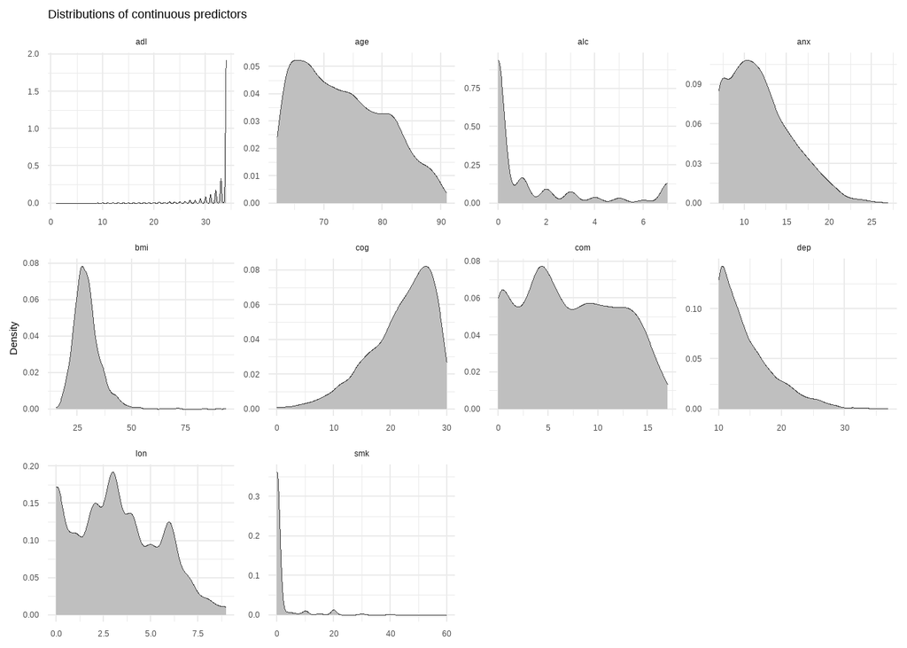

```r
if (length(contvars) > 0) {
  df_cont <- data %>%
    select(all_of(contvars)) %>%
    pivot_longer(everything(), names_to = "variable", values_to = "value") %>%
    filter(!is.na(value))

  print(
    ggplot(df_cont, aes(x = value)) +
      geom_density(fill = "grey75", color = "grey25", linewidth = 0.3) +
      facet_wrap(~ variable, scales = "free") +
      theme_minimal() +
      labs(title = "Distributions of continuous predictors", x = NULL, y = "Density"))}
```

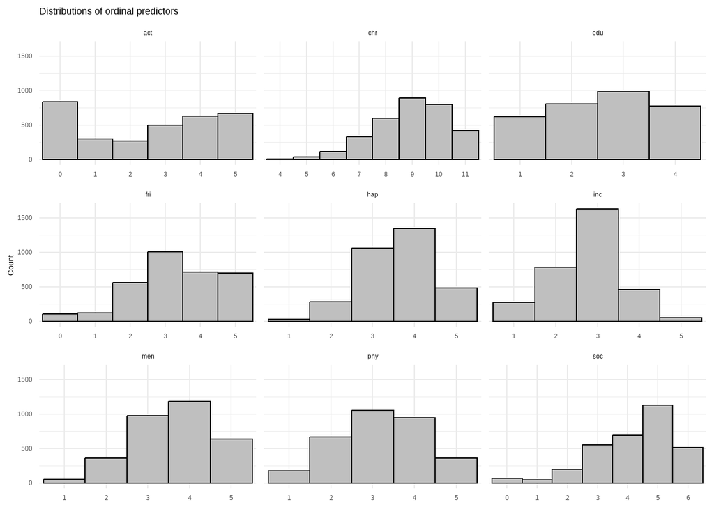

```r
if (length(ordvars) > 0) {
  df_ord <- data %>%
    select(all_of(ordvars)) %>%
    pivot_longer(everything(), names_to = "variable", values_to = "value") %>%
    filter(!is.na(value)) %>%
    mutate(value = as.ordered(value))

  print(
    ggplot(df_ord, aes(x = value)) +
      geom_bar(fill = "grey75", color = "black", width = 1) +
      facet_wrap(~ variable, scales = "free_x") +
      theme_minimal() +
      labs(title = "Distributions of ordinal predictors", x = NULL, y = "Count"))}
```

```r
if (length(catvars) > 0) {
  df_cat <- data %>%
    select(all_of(catvars)) %>%
    pivot_longer(everything(), names_to = "variable", values_to = "value") %>%
    filter(!is.na(value)) %>%
    mutate(value = fct_infreq(as.factor(value)))

  print(
    ggplot(df_cat, aes(x = value)) +
      geom_bar(fill = "grey75", color = "black", width = 0.7) +
      facet_wrap(~ variable, scales = "free_x") +
      theme_minimal() +
      theme(axis.text.x = element_text(angle = 45, hjust = 1)) +
      labs(title = "Distributions of categorical predictors", x = NULL, y = "Count"))}
```

# Skewness

Skewness was detected with the **dlookr** package (Ryu, 2025).

**Author**: Ryu, C. (2025). *Package ‘dlookr’* [R package]. CRAN.

```r
data %>% find_skewness(index = FALSE, value = TRUE, thres = 0.5) %>% print()
```

```
##    chr    adl    cog    soc    alc    smk    dep    anx    bmi
## -0.506 -3.690 -0.927 -0.879  1.690  4.290  1.355  0.755  1.922
```

# Correlations

Spearman correlations computed with rcorr() from the **hmisc** package (Harrell, 2019).

**Author**: Harrell Jr, F. E., & Harrell Jr, M. F. E. (2019). *Package ‘hmisc’* [R package]. CRAN.

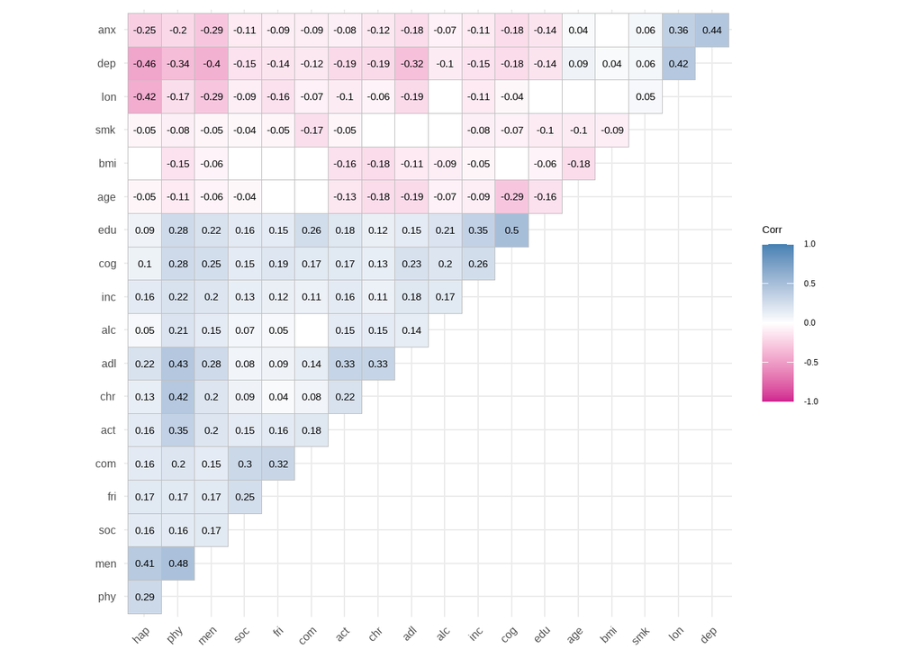

```r
df_num <- data[, colnames(data)]
cor_res <- rcorr(as.matrix(df_num), type = "spearman")
cor_matrix <- cor_res$r
p_matrix <- cor_res$P

ggcorrplot(
  cor_matrix
, hc.order = TRUE,
, type = "upper"
, lab = TRUE,
, p.mat = p_matrix
, sig.level = 0.05
, insig = "blank"
, colors = c("violetred"
           , "white"
           , "steelblue"))
```

# Assumptions

Positive definitiveness was assessed with the **matrixcalc** package (Novomestky & Kelly, 2022).

**Author**: Novomestky, F., & Kelly, M. S. T. (2022). *Package ‘matrixcalc’.* [R Package]. CRAN.

```r
cormat <- cor(x = data, use = c("pairwise.complete.obs"))
is.positive.definite(cormat)
```

```
## [1] TRUE
```

# Variable redundancy

Variable redundancy assessed with the **networktools** package (Jones & Jones, 2018).

**Author**: Jones, P., & Jones, M. P. (2018). *Package ‘networktools’.* [R Package]. CRAN.

```r
goldbricker(
  data, p = 0.05
, method = "hittner2003"
, threshold = 0.25
, corMin = 0.5
, progressbar = FALSE)
```

```
## Suggested reductions: Less than 25 % of correlations are significantly different for the following pairs:
## [1] "No suggested reductions"
```

# Network estimation

Network was estimated with the **bootnet** package (Epskamp & Fried, 2025).

**Author**: Epskamp, S., & Fried, E. I. (2025). *Package ‘bootnet’* [R package]. CRAN.

```r
set.seed(seed)

network <- estimateNetwork(
  data = data
, stepwise = TRUE
, default = "ggmModSelect"
, corMethod = "spearman")

save(network, file = "network.RData")
```

```r
load("network.RData")
```

```r
boots <- 1000
nCores <- parallel::detectCores() - 2
```

```r
set.seed(seed)

test <- as.matrix(data)
cols <- ncol(test)
```

# Predictability

```r
set.seed(seed)
fit_obj <- mgm(
  data = test
, type = rep('g', cols)
, level = rep('1',cols)
, lambdSel = 'EBIC',
ruleReg = 'OR')

predictability <- predict(
  object = fit_obj,
  data = test,
  errorCon = 'R2')

save(predictability, file = "predictability.RData")
```

```r
load("predictability.RData")
```

# Network simulation

Network simulation with **bootnet** package (Epskamp & Fried, 2025).

**Author**: Epskamp, S., & Fried, E. I. (2025). *Package ‘bootnet’* [R package]. CRAN.

```r
sims <- netSimulator(
  network$graph
, nCases = c(1000, 2000, 3196)
, nReps = boots
, nCores = nCores
, default = "ggmModSelect"
, stepwise  = TRUE
, corMethod = "spearman")

save(sims, file = "sims.RData")
```

```r
load("sims.RData")
```

# Node Groups

```r
indexg1 <- c(1:5)
indexg2 <- c(6:19)

groups = list(
  "Successful Ageing" = indexg1
, "Influencing Factors" = indexg2)
```

# Network stability

```r
bootnp1 <- bootnet(
  network
, type = "nonparametric"
, nBoots = boots
, split  = TRUE
, nCores = nCores
, statistics = c("edge"))

save(bootnp1, file = "bootnp1.RData")

bootnp2 <- bootnet(
  network
, nBoots = boots
, type = "nonparametric"
, nCores = nCores
, statistics = c("bridgeExpectedInfluence")
, communities = groups)

save(bootnp2, file = "bootnp2.RData")

bootcd <- bootnet(
  network
, nBoots = boots
, type = "case"
, nCores = nCores
, statistics = c("bridgeExpectedInfluence",
                 "edge")
, communities = groups)

save(bootcd, file = "bootcd.RData")
```

```r
load("bootnp1.RData")
load("bootnp2.RData")
load("bootcd.RData")
```

# Edge stability

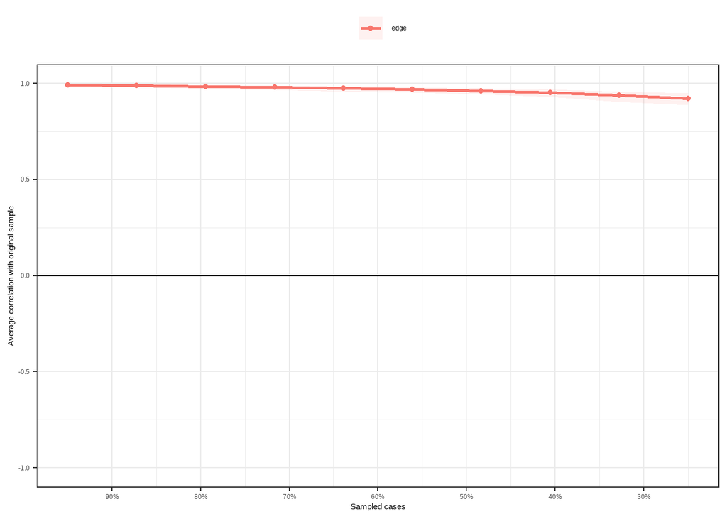

```r
# bridge stability graphs
bootcd %>% plot(
order = "sample"
, labels = TRUE
, statistics = c("edge")
, communities = groups)
```

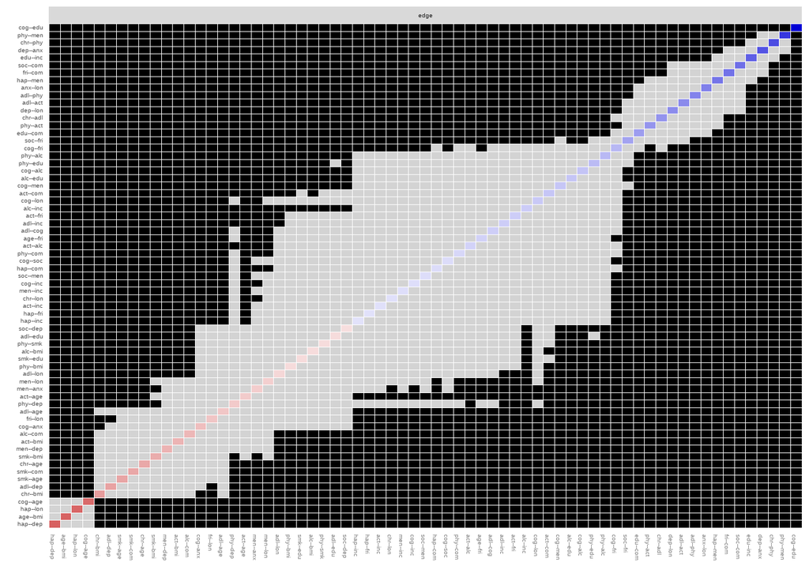

```r
# edge stability graphs

bootnp1 %>% plot("edge", plot = "difference", onlyNonZero = TRUE, order = "sample")
```

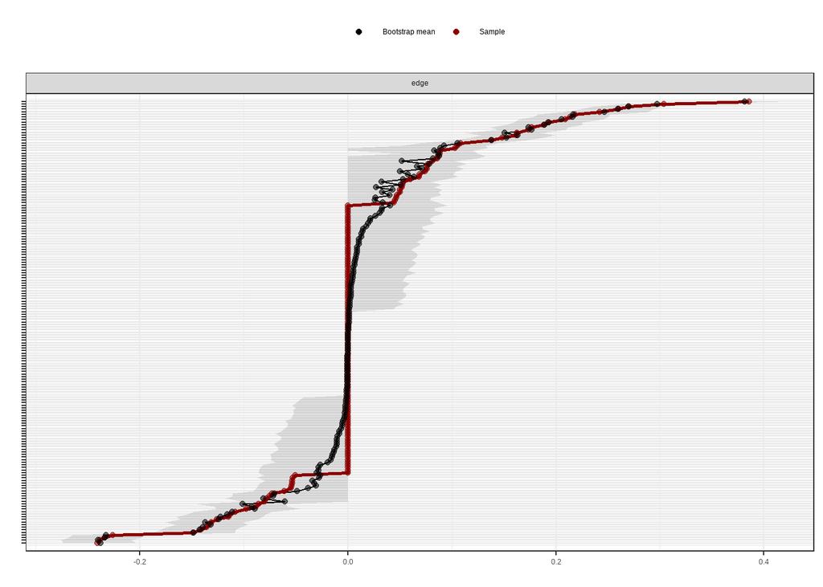

```r
bootnp1 %>% plot(labels = FALSE, order = "sample")
```

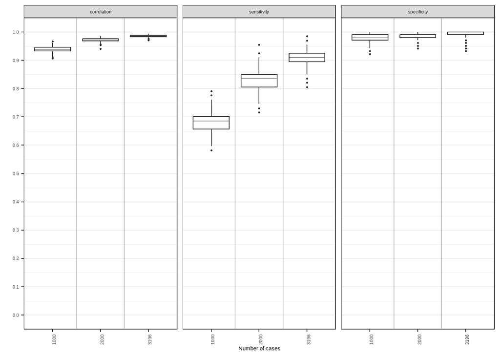

```r
sims %>% plot()
```

# Bridge centrality

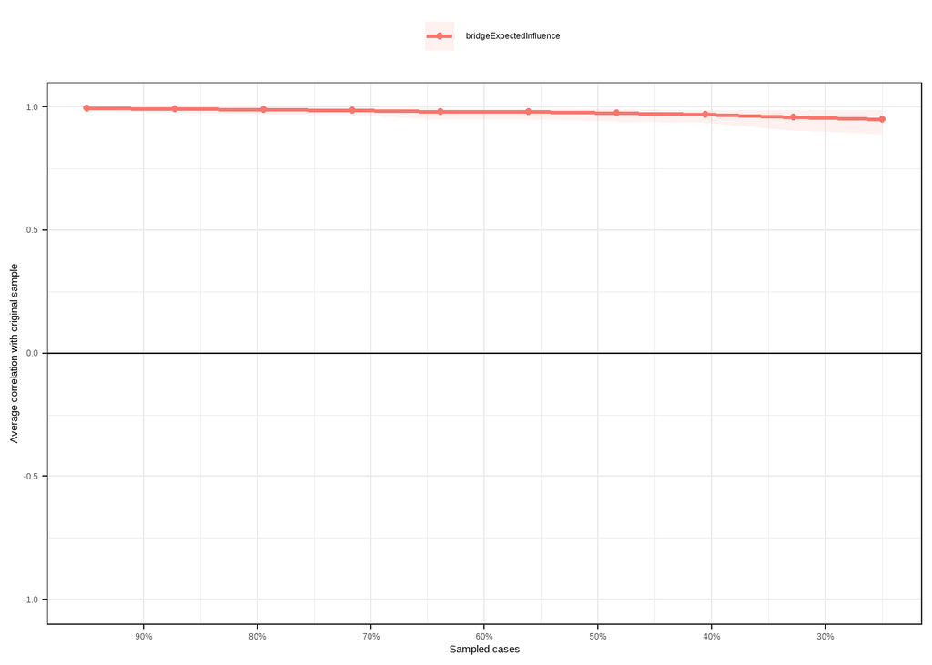

```r
# bridge stability graphs
bootcd %>% plot(
order = "sample"
, labels = TRUE
, statistics = c("bridgeExpectedInfluence")
, communities = groups)
```

```r
# stability coefficients
corStability(bootcd) # Bad (0-0.2), Acceptable (0.2-0.5), Good (0.5-0.7), Excellent (0.7-1).
```

```
## === Correlation Stability Analysis ===
##
## Sampling levels tested:
##    nPerson Drop%   n
## 1      799  75.0 101
## 2     1048  67.2 110
## 3     1296  59.4  90
## 4     1545  51.7 107
## 5     1793  43.9  96
## 6     2042  36.1 111
## 7     2290  28.3  84
## 8     2539  20.6 107
## 9     2788  12.8 104
## 10    3036   5.0  90
##
## Maximum drop proportions to retain correlation of 0.7 in at least 95% of the samples:
##
## bridgeExpectedInfluence: 0.75 (CS-coefficient is highest level tested)
##   - For more accuracy, run bootnet(..., caseMin = 0.672, caseMax = 1)
##
## edge: 0.75 (CS-coefficient is highest level tested)
##   - For more accuracy, run bootnet(..., caseMin = 0.672, caseMax = 1)
##
## Accuracy can also be increased by increasing both 'nBoots' and 'caseN'.
```

```r
bridge <- bridge(network$graph
, communities = c(rep('1', 5), rep('2', 14))
, useCommunities = "all"
, directed = NULL
, nodes = NULL)

# bridge values
bridge %>% print()
```

```
## $`Bridge Strength`
##        chr        adl        phy        cog        soc        hap        men
## 0.32708149 0.59348028 0.92229747 1.12451456 0.45938628 0.00000000 0.44251679
##        act        alc        smk        age        edu        fri        inc
## 0.33854595 0.19390058 0.05333053 0.44302998 0.54217113 0.24671371 0.12613984
##        dep        anx        lon        com        bmi
## 0.27171069 0.09771862 0.18896709 0.27847664 0.20353855
##
## $`Bridge Betweenness`
## chr adl phy cog soc hap men act alc smk age edu fri inc dep anx lon com bmi
##   0   0  14   9   0   0   4   7   0   0   0  15   5   0   0   0  10   8   0
##
## $`Bridge Closeness`
##        chr        adl        phy        cog        soc        hap        men
## 0.05258350 0.05253817 0.05855957 0.07634424 0.05182422 0.06834975 0.10078130
##        act        alc        smk        age        edu        fri        inc
## 0.08866347 0.07000530        NaN 0.03328538 0.09623990 0.06432024 0.07497291
##        dep        anx        lon        com        bmi
## 0.03596656 0.03673120 0.04537303 0.07380037        NaN
##
## $`Bridge Expected Influence (1-step)`
##         chr         adl         phy         cog         soc         hap
## -0.23305589 -0.08863776  0.54665683  0.47676111  0.35856024  0.00000000
##         men         act         alc         smk         age         edu
##  0.44251679  0.33854595  0.19390058 -0.05333053 -0.44302998  0.43602527
##         fri         inc         dep         anx         lon         com
##  0.24671371  0.12613984 -0.27171069 -0.09771862  0.06729410  0.27847664
##         bmi
## -0.20353855
##
## $`Bridge Expected Influence (2-step)`
##         chr         adl         phy         cog         soc         hap
##  0.02845382  0.06277812  0.59336316  0.76420809  0.48028593  0.17359949
##         men         act         alc         smk         age         edu
##  0.63557386  0.60747108  0.30583968 -0.05260953 -0.51899841  0.60211108
##         fri         inc         dep         anx         lon         com
##  0.31670144  0.32317408 -0.43563085 -0.20116210 -0.04779716  0.45042566
##         bmi
## -0.22960921
##
## $communities
##  [1] "1" "1" "1" "1" "1" "2" "2" "2" "2" "2" "2" "2" "2" "2" "2" "2" "2" "2" "2"
```

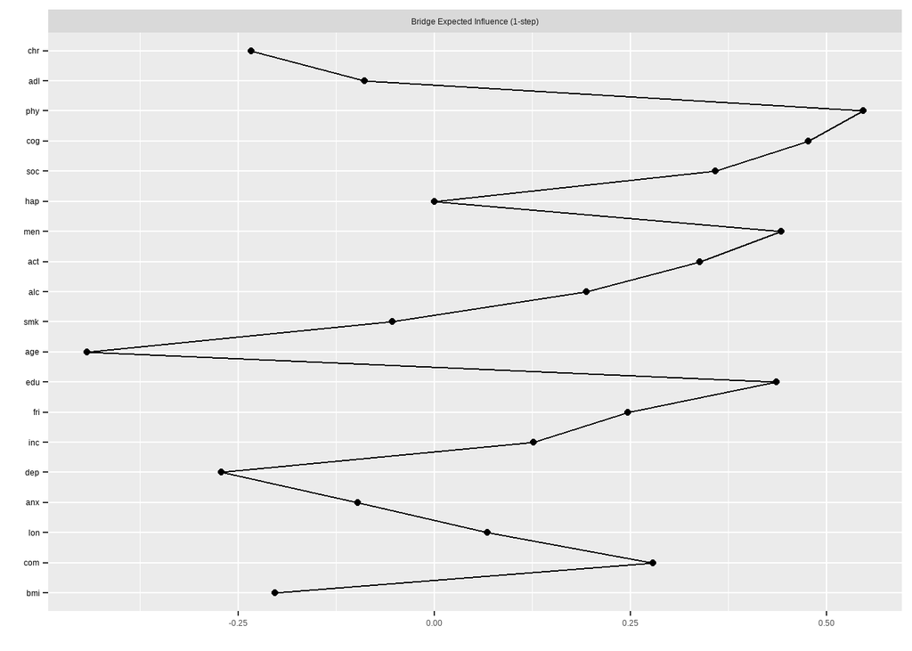

```r
plot(bridge, include = "Bridge Expected Influence (1-step)", width = 4)
```

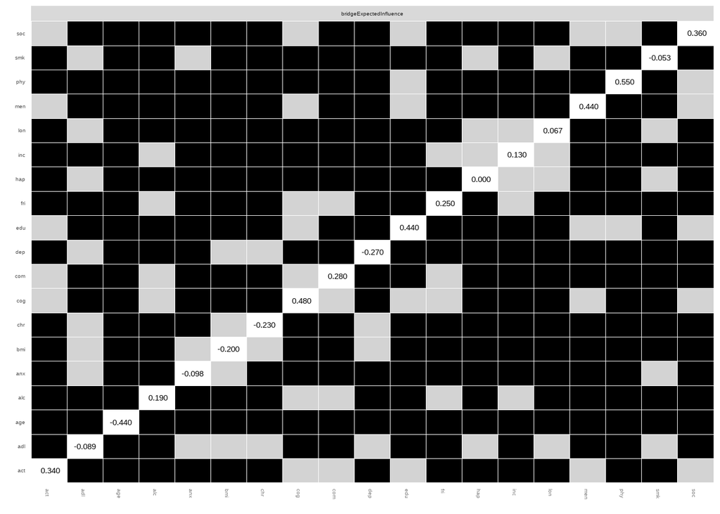

```r
# bridge different test
bootnp2 %>% plot(statistics = "bridgeExpectedInfluence", plot = "difference")
```

# Community detection

```r
inetwork <- graph_from_adjacency_matrix(
  abs(as.matrix(network$graph))
, mode = "undirected"
, weighted = TRUE
, diag = FALSE)

algorithms <- list(
  spinglass = cluster_spinglass
, walktrap = cluster_walktrap
, louvain = cluster_louvain
, fast_greedy = cluster_fast_greedy)

results <- list()
for (algo_name in names(algorithms)) {
  com <- algorithms[[algo_name]](inetwork)
  results[[algo_name]] <- list(
    modularity = max(com$modularity),
    membership = com$membership)
  cat(algo_name, "modularity:", results[[algo_name]]$modularity, "\n")}
```

```
## spinglass modularity: -14.43815
## walktrap modularity: 0.3552157
## louvain modularity: 0.3552157
## fast_greedy modularity: 0.3168442
```

```r
best <- names(which.max(sapply(results, function(x) x$modularity)))
community <- results[[best]]$membership
cat("Best algorithm:", best, "\n")
```

```
## Best algorithm: walktrap
```

```r
communitygroups <- as.list(community)
communitynumber <- length(unique(community))
```

# Network plot

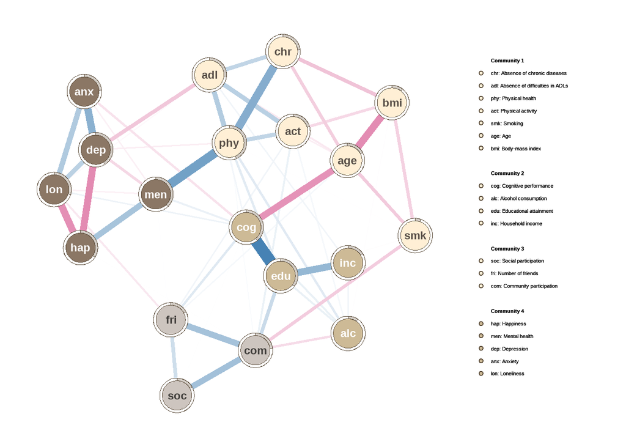

```r
node_labels <- colnames(data)
node_names <- c(
  "Absence of chronic diseases"
, "Absence of difficulties in ADLs"
, "Physical health"
, "Cognitive performance"
, "Social participation"
, "Happiness"
, "Mental health"
, "Physical activity"
, "Alcohol consumption"
, "Smoking"
, "Age"
, "Educational attainment"
, "Number of friends"
, "Household income"
, "Depression"
, "Anxiety"
, "Loneliness"
, "Community participation"
, "Body-mass index")

communitygroups <- lapply(unique(community), function(comm_num) {which(community == comm_num)})
names(communitygroups) <- paste("Community", 1:length(communitygroups))

communityplot <- plot(

# network
  network
, layout = "spring"
, bidirectional = FALSE
, directed = FALSE
, minimum = 0.05
, GLratio = 3

# edges
, posCol = "steelblue"
, negCol = "violetred3"
, esize = 15
, edge.width = 1
, edge.labels = FALSE
, edge.label.cex = 1

# nodes
, shape = "circle"
, vsize = 6
, border.color = "#5b4c3a"
#, pie = nodeexplained
, pie = as.numeric(
        as.character(predictability$error[,2]))
, pieColor = rep("#D2CCC5", cols)

# labels
, label = node_labels
, label.font = 2
, label.scale.equal = TRUE
, nodeNames = node_names

# legend
, legend = TRUE
, legend.mode = "style1"
, legend.cex = 0.35

# community
, color = c(
  "papayawhip"
, "peachpuff4"
, "wheat3"
, "seashell3"
, "antiquewhite"
, "bisque3"
, "navajowhite")[1:max(community)][community]
, label.color = c(
  "#564D46"
, "gray100"
, "white"
, "#3F3D3A"
, "#564D46"
, "#564D46"
, "#564D46")[1:max(community)][community]
, groups = communitygroups)
```

# Print network

```r
pdf(file = "plot.pdf", width = 8, height = 6)
plot(communityplot)
dev.off()
browseURL("plot.pdf")
```

# Network metrics

```r
A <- network$graph
A <- as.matrix(A)

A_bin <- (A != 0) * 1

g <- graph_from_adjacency_matrix(A_bin, mode = "undirected", diag = FALSE)

avg_degree  <- mean(igraph::degree(g))
avg_spl     <- mean_distance(g, directed = FALSE, unconnected = TRUE)  # ignores unreachable pairs
gcc         <- igraph::transitivity(g, type = "global") # global clustering coefficient
density     <- edge_density(g, loops = FALSE)
diameter_g  <- diameter(g, directed = FALSE, unconnected = TRUE)

list(
  average_degree = avg_degree,
  average_shortest_path_length = avg_spl,
  global_clustering_coefficient = gcc,
  density = density,
  diameter = diameter_g
)
```

```
## $average_degree
## [1] 7.052632
##
## $average_shortest_path_length
## [1] 1.654971
##
## $global_clustering_coefficient
## [1] 0.4186047
##
## $density
## [1] 0.3918129
##
## $diameter
## [1] 3
```